# Identifying Age-Related Conditions

## What

The objective of this project is to develop a predictive model that can determine whether a person has any of three specific medical conditions. The task involves classifying individuals into two groups: Class 1, which signifies the presence of one or more of the three medical conditions, and Class 0, indicating the absence of any of these conditions. The model will be trained using health characteristic measurements.

## Why

Traditionally, identifying these medical conditions requires a lengthy and invasive process of gathering information directly from patients. However, with the implementation of predictive models, we can streamline this process by collecting essential health characteristics related to the conditions and encoding them while ensuring the privacy and confidentiality of patient data.

## How

We will do Lasso Regression, Regression Tree, Neural Network, and XGBoosted Random Forest

## TOC:

- Exploritory Analysis
- Models
  - Lasso Regression
  - Decision Tree
  - Neural Network
  - XGBoost Classifier
- Exporting Results

```python
import numpy as np
import pandas as pd
import matplotlib.pyplot as plt
import tensorflow.compat.v1 as tf
from sklearn.preprocessing import StandardScaler
from sklearn.model_selection import train_test_split
from imblearn.over_sampling import RandomOverSampler
```

```python
train = pd.read_csv("/Users/jakebentley/Desktop/ICR/train.csv")
train.head()
```

|  | Id | AB | AF | AH | AM | AR | AX | AY | AZ | BC | ... | FL | FR | FS | GB | GE | GF | GH | GI | GL | Class |
| --- | --- | --- | --- | --- | --- | --- | --- | --- | --- | --- | --- | --- | --- | --- | --- | --- | --- | --- | --- | --- | --- |
| 0 | 000ff2bfdfe9 | 0.209377 | 3109.03329 | 85.200147 | 22.394407 | 8.138688 | 0.699861 | 0.025578 | 9.812214 | 5.555634 | ... | 7.298162 | 1.73855 | 0.094822 | 11.339138 | 72.611063 | 2003.810319 | 22.136229 | 69.834944 | 0.120343 | 1 |
| 1 | 007255e47698 | 0.145282 | 978.76416 | 85.200147 | 36.968889 | 8.138688 | 3.632190 | 0.025578 | 13.517790 | 1.229900 | ... | 0.173229 | 0.49706 | 0.568932 | 9.292698 | 72.611063 | 27981.562750 | 29.135430 | 32.131996 | 21.978000 | 0 |
| 2 | 013f2bd269f5 | 0.470030 | 2635.10654 | 85.200147 | 32.360553 | 8.138688 | 6.732840 | 0.025578 | 12.824570 | 1.229900 | ... | 7.709560 | 0.97556 | 1.198821 | 37.077772 | 88.609437 | 13676.957810 | 28.022851 | 35.192676 | 0.196941 | 0 |
| 3 | 043ac50845d5 | 0.252107 | 3819.65177 | 120.201618 | 77.112203 | 8.138688 | 3.685344 | 0.025578 | 11.053708 | 1.229900 | ... | 6.122162 | 0.49706 | 0.284466 | 18.529584 | 82.416803 | 2094.262452 | 39.948656 | 90.493248 | 0.155829 | 0 |
| 4 | 044fb8a146ec | 0.380297 | 3733.04844 | 85.200147 | 14.103738 | 8.138688 | 3.942255 | 0.054810 | 3.396778 | 102.151980 | ... | 8.153058 | 48.50134 | 0.121914 | 16.408728 | 146.109943 | 8524.370502 | 45.381316 | 36.262628 | 0.096614 | 1 |

5 rows × 58 columns

## Exploratory Data Analysis

Lets look at Missing Data

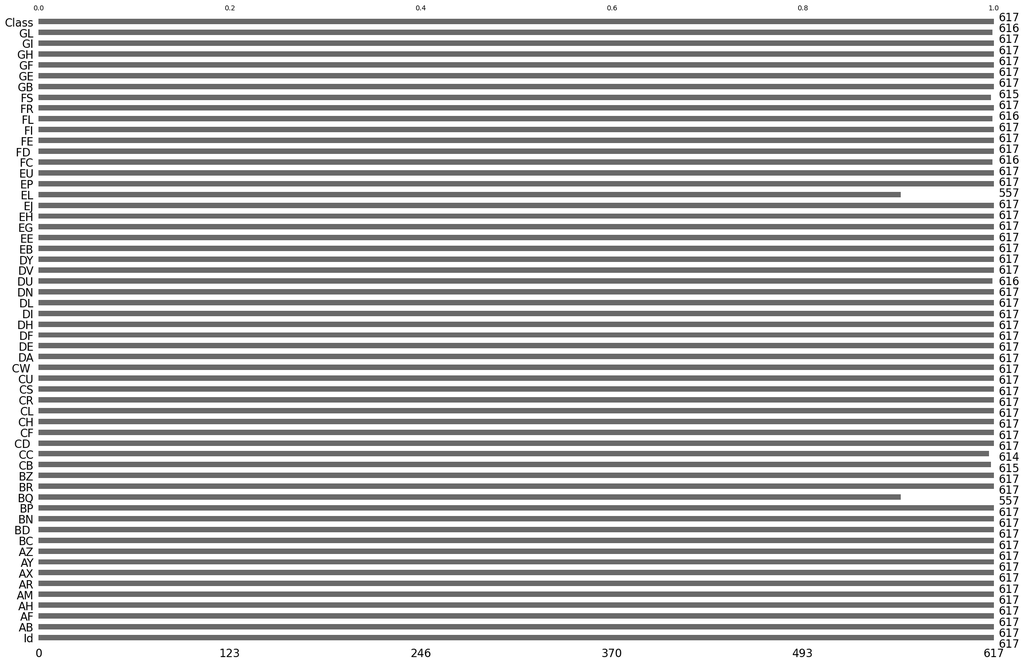

```python
import missingno as msno
msno.bar(train)
```

We don't need Id since it is has no predictive value at all

```python
train = train.drop(['Id'],axis = 1)
```

We want to change the EJ variable so that we can make a histogram with it

```python
for i in range(len(train.EJ)):
    if train.loc[i, 'EJ'] == 'B':
        train.loc[i, 'EJ'] = 1
    else:
        train.loc[i, 'EJ'] = 0
```

We want to fill in any missing values with the mean

```python
for i in range(len(train.columns[:-1])):
    label = train.columns[i]
    train[label] = train[label].fillna(round(train[label].mean(),2))
```

We want to start with the most basic stuff

```python
train.describe()
```

|  | AB | AF | AH | AM | AR | AX | AY | AZ | BC | BD | ... | FL | FR | FS | GB | GE | GF | GH | GI | GL | Class |
| --- | --- | --- | --- | --- | --- | --- | --- | --- | --- | --- | --- | --- | --- | --- | --- | --- | --- | --- | --- | --- | --- |
| count | 617.000000 | 617.000000 | 617.000000 | 617.000000 | 617.000000 | 617.000000 | 617.000000 | 617.000000 | 617.000000 | 617.000000 | ... | 617.000000 | 617.000000 | 617.000000 | 617.000000 | 617.000000 | 617.000000 | 617.000000 | 617.000000 | 617.000000 | 617.000000 |
| mean | 0.477149 | 3502.013221 | 118.624513 | 38.968552 | 10.128242 | 5.545576 | 0.060320 | 10.566447 | 8.053012 | 5350.388655 | ... | 5.433194 | 3.533905 | 0.421496 | 20.724856 | 131.714987 | 14679.595398 | 31.489716 | 50.584437 | 8.530959 | 0.175041 |
| std | 0.468388 | 2300.322717 | 127.838950 | 69.728226 | 10.518877 | 2.551696 | 0.416817 | 4.350645 | 65.166943 | 3021.326641 | ... | 11.486922 | 50.181948 | 1.303244 | 9.991907 | 144.181524 | 19352.959387 | 9.864239 | 36.266251 | 10.318624 | 0.380310 |
| min | 0.081187 | 192.593280 | 85.200147 | 3.177522 | 8.138688 | 0.699861 | 0.025578 | 3.396778 | 1.229900 | 1693.624320 | ... | 0.173229 | 0.497060 | 0.067730 | 4.102182 | 72.611063 | 13.038894 | 9.432735 | 0.897628 | 0.001129 | 0.000000 |
| 25% | 0.252107 | 2197.345480 | 85.200147 | 12.270314 | 8.138688 | 4.128294 | 0.025578 | 8.129580 | 1.229900 | 4155.702870 | ... | 0.173229 | 0.497060 | 0.067730 | 14.036718 | 72.611063 | 2798.992584 | 25.034888 | 23.011684 | 0.124414 | 0.000000 |
| 50% | 0.354659 | 3120.318960 | 85.200147 | 20.533110 | 8.138688 | 5.031912 | 0.025578 | 10.461320 | 1.229900 | 4997.960730 | ... | 3.036891 | 1.131000 | 0.257374 | 18.771436 | 72.611063 | 7838.273610 | 30.608946 | 41.007968 | 0.339429 | 0.000000 |
| 75% | 0.559763 | 4361.637390 | 113.739540 | 39.139886 | 8.138688 | 6.431634 | 0.036845 | 12.969516 | 5.081244 | 6035.885700 | ... | 6.237329 | 1.512060 | 0.535067 | 25.608406 | 127.591671 | 19035.709240 | 36.863947 | 67.931664 | 21.978000 | 0.000000 |
| max | 6.161666 | 28688.187660 | 1910.123198 | 630.518230 | 178.943634 | 38.270880 | 10.315851 | 38.971568 | 1463.693448 | 53060.599240 | ... | 137.932739 | 1244.227020 | 31.365763 | 135.781294 | 1497.351958 | 143790.071200 | 81.210825 | 191.194764 | 21.978000 | 1.000000 |

8 rows × 57 columns

Here we see the a lot of our variables are on different scales. We can also tell from our Class mean that there are a lot more not sick then sick These are all important things that need to be addressed

We normalize the columns by scaling their quantities

```python
X = train[train.columns[:-1]].values
y = train[train.columns[-1]].values

scaler = StandardScaler()
X = scaler.fit_transform(X)
```

Next we make the the data has an even number of sick and not sick cases

```python
over = RandomOverSampler()
X, y = over.fit_resample(X, y)
```

Then we join the dataframe back together

```python
data = np.hstack((X, np.reshape(y, (-1,1))))
transformed_train = pd.DataFrame(data, columns = train.columns)
```

Here we compare the distribution of each variable with class sick and class not sick (We are only going to show first 10 here)

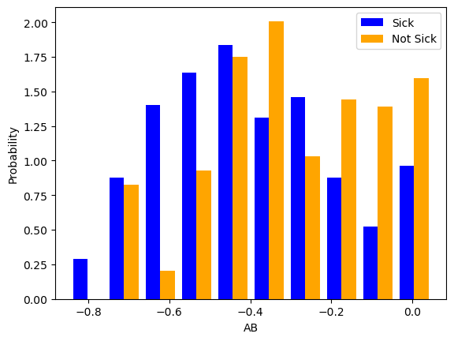

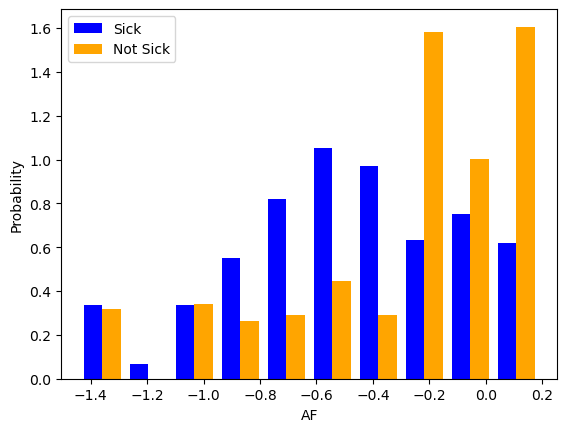

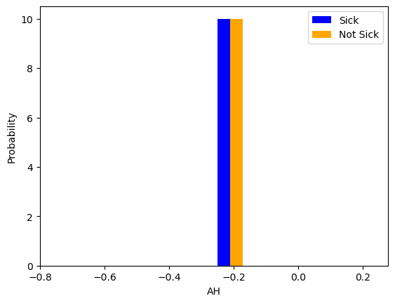

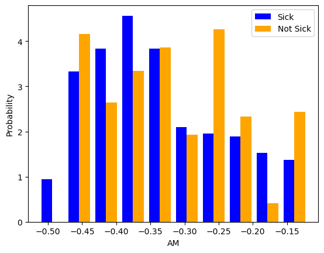

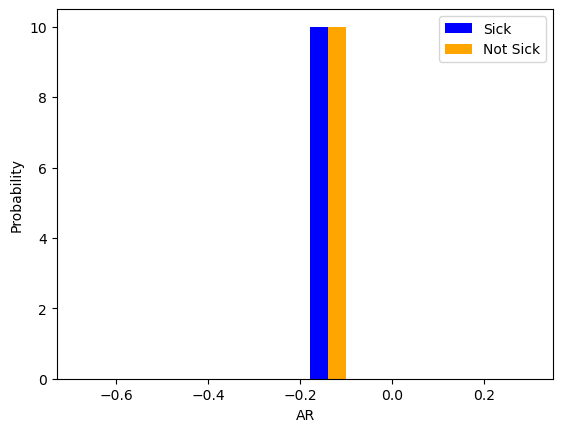

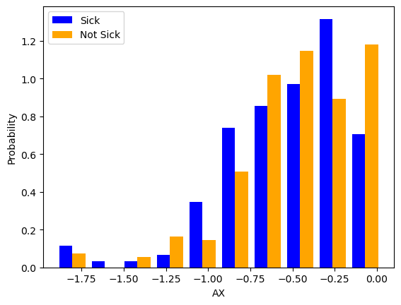

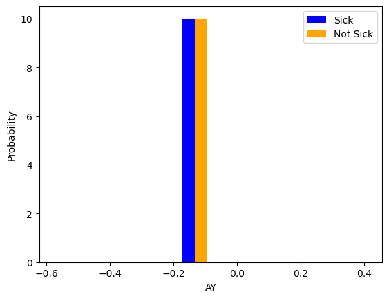

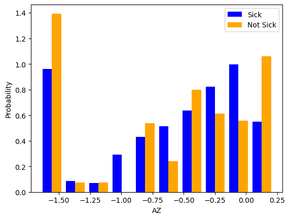

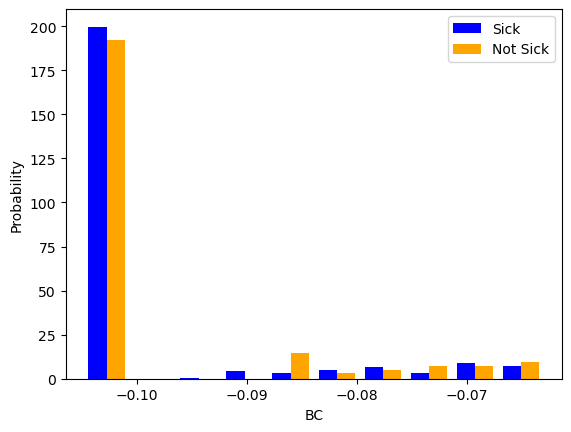

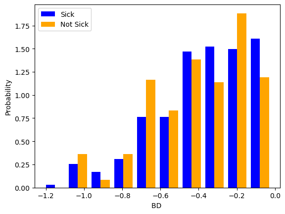

```python
for i in range(10):
    label = train.columns[i]
    n = 600
    sorted_array = transformed_train.nsmallest(n, label)
    #We only want to graph the lowest 600 values because a lot of time there are outliers that will
    #make our histograms look very lopsided
    plt.hist(sorted_array.pivot(columns='Class', values=label), color = ('blue','orange'), label = ('Sick','Not Sick'),
         density = True)
    plt.ylabel("Probability")
    plt.xlabel(label)
    plt.legend()
    plt.show()
```

From the graphs we have marked down categories that seem to have good markers: AB, AF, AX, BC, BN, BP, BQ, CR, DA, DF, DI, DU, EB, EH, EJ, FE, FL, GF, GL (weird one). This is a lot of the categories but I think diving into them can give us some key insights

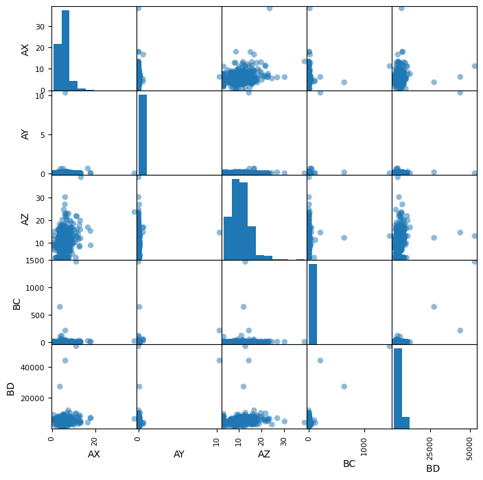

```python
_ = pd.plotting.scatter_matrix(train[list(transformed_train.columns[5:10])], figsize = [8, 8], s=150)
```

After looking at several scatter_matrices these characteristics don't seem to be very heaviliy correlated

## Now we want to create our models

### We will do Lasso Regression, Regression Tree, Neural Network, and XGBoosted Random Forest

First we need to figure out how to measure how good our model is. We use the balanced_log_loss model

```python
from sklearn.metrics import log_loss
def balanced_log_loss(y_test, y_pred):
    nc = np.bincount(y_test)
    return log_loss(y_test, y_pred, sample_weight = 1/nc[y_test], eps=1e-7)
```

Split our data

```python
X_train, X_temp, y_train, y_temp = train_test_split(X, y, test_size = 0.4,
                                                   random_state = 5)
X_valid, X_test, y_valid, y_test = train_test_split(X_temp, y_temp,
                                                   test_size = 0.5,
                                                   random_state = 5)
```

Import necessary packages

```python
from sklearn.model_selection import cross_val_score, train_test_split, GridSearchCV
from sklearn.linear_model import LinearRegression, ElasticNet, Ridge, Lasso
from sklearn.tree import DecisionTreeRegressor
from sklearn.pipeline import Pipeline
from sklearn.metrics import mean_squared_error as MSE
from sklearn.metrics import r2_score
from sklearn.preprocessing import scale, PolynomialFeatures
```

Lets tune our Lasso regression model and fit it to the data

```python
alphas = np.linspace(0, 0.9, 36)
LassoReg = Lasso()
alpha_df = { 'alpha': np.linspace(0.01, 0.9, 36)}

LassoReg_Tune = GridSearchCV(LassoReg, alpha_df, scoring='neg_mean_squared_error', cv=5, n_jobs=-1)

results = LassoReg_Tune.fit(X_train, y_train)

best_alpha = results.best_params_['alpha']

print('MSE: ' + str(results.best_score_))
print('Config: ' + str(results.best_params_))
```

```
MSE: -0.1223260764784998
Config: {'alpha': 0.01}
```

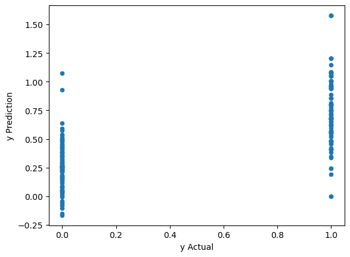

```python
LassoReg = Lasso(alpha = best_alpha)

LassoReg.fit(X_train,y_train)

y_pred_las = LassoReg.predict(X_test)

#Create a datafram so that we can plot Actual SDD versus Predicted SDD
lassodf = pd.DataFrame()
lassodf['y Actual'] = y_test
lassodf['y Prediction'] = y_pred_las
lassodf.plot.scatter(x = 'y Actual', y = 'y Prediction')
```

```python
balanced_log_loss(y_test,y_pred_las)
```

```
0.5855730119721273
```

Not very Good

Now we are going to use the decision tree model

```python
DecTre = DecisionTreeRegressor(random_state = 3)
params_dectre = {'max_depth': [3, 4, 5, 6],
             'min_samples_leaf': [0.04, 0.06, 0.08],
             'max_features': [0.2, 0.4,0.6, 0.8]
            }

#Instantiate a 5fold CV grid search object
grid_dectre = GridSearchCV(estimator=DecTre,
                       param_grid=params_dectre,
                       scoring='neg_mean_squared_error',
                       cv=5,
                       n_jobs=-1)

#Fit grid_dectre to the data
grid_dectre.fit(X_train, y_train)

best_parameters = grid_dectre.best_params_
print('Using cross validation and tuning the best MSE was: ' + str(grid_dectre.best_score_))
print('Best hyerparameters:\n', best_parameters)
```

```
Using cross validation and tuning the best MSE was: -0.10016864125356328
Best hyerparameters:
 {'max_depth': 5, 'max_features': 0.4, 'min_samples_leaf': 0.04}
```

```python
DecTre_best_model = grid_dectre.best_estimator_

# Predict the test set labels
y_pred_dtr = DecTre_best_model.predict(X_test)

mse = MSE(y_test, y_pred_dtr)
r2 = r2_score(y_test,y_pred_dtr)
print("(When tested on test set) Mean Squared Error of Decision Tree Regression Model was: " + str(mse))
print("(When tested on test set) R2 Squared Value of Decision Tree Regression Model was: " + str(r2))
```

```
(When tested on test set) Mean Squared Error of Decision Tree Regression Model was: 0.12657788956158372
(When tested on test set) R2 Squared Value of Decision Tree Regression Model was: 0.49349370653895486
```

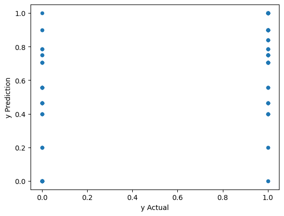

```python
Treedf = pd.DataFrame()
Treedf['y Actual'] = y_test
Treedf['y Prediction'] = y_pred_dtr
Treedf.plot.scatter(x = 'y Actual', y = 'y Prediction')
```

```python
balanced_log_loss(y_test,y_pred_dtr)
```

```
0.5602244189653718
```

Not good

## Neural Network

Now we prep our neural network and train it

```python
model = tf.keras.Sequential([
    tf.keras.layers.Dense(16, activation = 'relu'),
    tf.keras.layers.Dense(16, activation = 'relu'),
    tf.keras.layers.Dense(1, activation = 'sigmoid')
])
```

```python
model.compile(optimizer = tf.keras.optimizers.Adam(learning_rate = 0.001),
            loss = tf.keras.losses.BinaryCrossentropy(),
            metrics=['accuracy'])
```

```python
model.evaluate(X_valid, y_valid)
```

```
[0.8438690900802612, 0.36274510622024536]
```

```python
model.fit(X_train, y_train, batch_size = 20, epochs = 40,
          validation_data = (X_valid, y_valid))
```

```
<keras.callbacks.History at 0x7fd099d2f460>
```

```python
model.evaluate(X_test, y_test)
```

```
[0.17524170875549316, 0.9509803652763367]
```

```python
y_pred = model.predict(X_test)
```

```python
balanced_log_loss(y_test,y_pred)
```

```
0.17804174135824619
```

Getting better!

# Now for XGBoost

```python
import xgboost as xgb
from sklearn.preprocessing import OrdinalEncoder

dtrain_reg = xgb.DMatrix(X_train, y_train, enable_categorical = True)
dtest_reg = xgb.DMatrix(X_test, y_test, enable_categorical = True)
```

Define hyperparameters, train XGBoost model

```python
params = {"objective": "binary:logistic", "tree_method": "hist"}

n = 10000

evals = [(dtest_reg, "validation"), (dtrain_reg, "train")]

model = xgb.train(
   params=params,
   dtrain=dtrain_reg,
   num_boost_round=n,
   evals=evals,
   verbose_eval=50,
   # Activate early stopping
   early_stopping_rounds=50
)
```

Here we gather our predictions

```python
preds = model.predict(dtest_reg)
```

Helps improve predictions

```python
for i in range(len(preds)):
    if preds[i] <= 0.5:
        preds[i] = 0
```

Plots our predicted versus true values

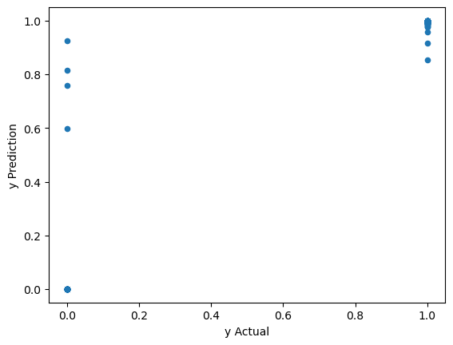

```python
Treedf = pd.DataFrame()
Treedf['y Actual'] = y_test
Treedf['y Prediction'] = preds
Treedf.plot.scatter(x = 'y Actual', y = 'y Prediction')
```

```python
balanced_log_loss(y_test,preds)
```

```
0.03658845475924916
```

This model performed the best so this is what we will use for our true predictions

```python
#We want to extract the top 10 markers
feature_important = model.get_score(importance_type='gain')

keys = list(feature_important.keys())
values = list(feature_important.values())

for feature in keys:
    i = int(feature.replace('f', ''))
    feature_important[train.columns[i]] = feature_important[feature]
    del feature_important[feature]
```

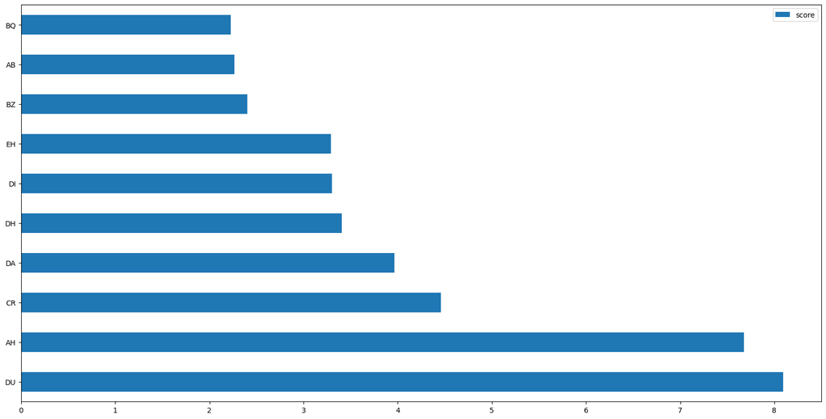

```python
keys = list(feature_important.keys())
data = pd.DataFrame(data=values, index=keys, columns=["score"]).sort_values(by = "score", ascending=False)
data.nlargest(10, columns="score").plot(kind='barh', figsize = (20,10)) ## plot top 40 features
```

## Exporting Results

```python
test_df = pd.read_csv('/Users/jakebentley/Desktop/ICR/test.csv')
test_ds_pd = test_df
test_df_columns = test_ds_pd.columns.tolist()
TEST_FEATURE_COLUMNS = [i for i in train.columns[:-1] \
                        if i in test_df_columns and i != "Class"]
test_ds_pd = test_ds_pd[TEST_FEATURE_COLUMNS]

#make into category
cats = test_ds_pd.select_dtypes(exclude=np.number).columns.tolist()

# Convert to Pandas category
for col in cats:
    test_ds_pd[col] = test_ds_pd[col].astype('category')


test_ds_xgb = xgb.DMatrix(test_ds_pd, enable_categorical = True)


predictions = model.predict(test_ds_xgb)


n_predictions= [[round(abs(i-1), 8), i] for i in predictions.ravel()]
print(n_predictions)
```

```
[[0.99986514, 0.00013486217], [0.99986514, 0.00013486217], [0.99986514, 0.00013486217], [0.99986514, 0.00013486217], [0.99986514, 0.00013486217]]
```

```python
sample_submission = pd.read_csv('/Users/jakebentley/Desktop/ICR/sample_submission.csv')
sample_submission[['class_0', 'class_1']] = n_predictions
sample_submission.to_csv('/Users/jakebentley/Desktop/ICR/submission.csv', index=False)
```